# Faunalytics Wildlife - Basic descriptives report

Sara Marín

23/02/2020

## INTRODUCTION

**This report is intended to show basic descriptives about a cleaned wildlife trade dataset** accesed with the lemis R package. This package provides access to the United States Fish and Wildlife Service’s (USFWS) Law Enforcement Management Information System (LEMIS) data on wildlife and wildlife product imports into the US. This data was obtained via more than 14 years of Freedom of Information Act (FOIA) requests by EcoHealth Alliance.

LEMIS wildlife trade data trends from 2000 through 2014. You can read more about this dataset [Here](https://www.nature.com/articles/s41597-020-0354-5)

### 1. Data Quality

#### 1.1. Missing values

**Only four variables have more than 30% missing values. Most of them are below 10%**

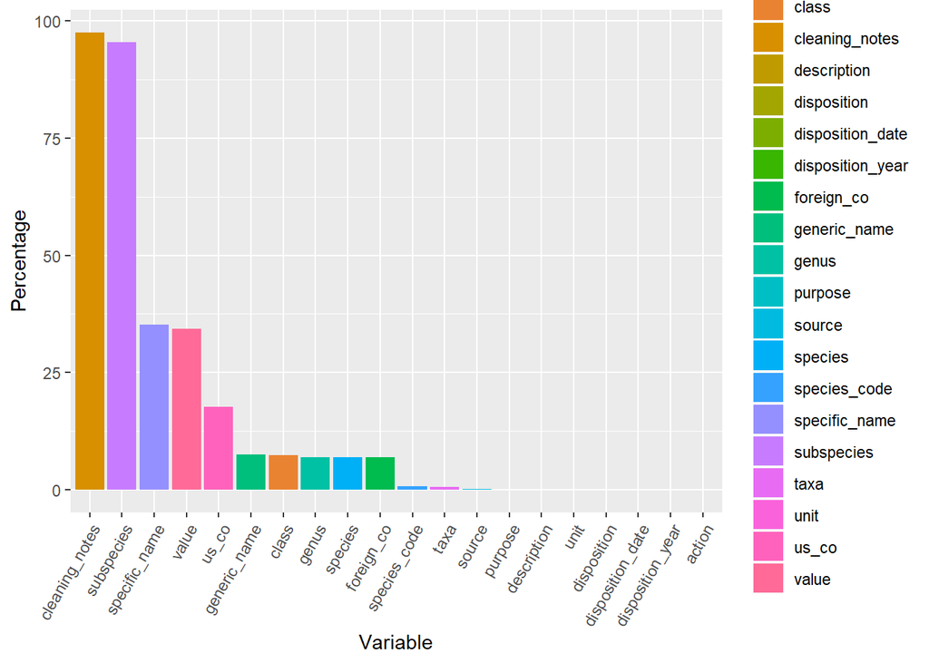

```r
# Are there missing values?
missing_values <- data %>%
  gather(key = "key", value = "val") %>%
  mutate(is.missing = is.na(val)) %>%
  group_by(key, is.missing) %>%
  summarise(num.missing = n()/nrow(data) *100) %>%
  filter(is.missing==T) %>%
  select(-is.missing) %>%
  arrange(desc(num.missing))


ggplot(missing_values, aes(x=reorder(key, -num.missing), y=num.missing, fill=key)) +
  geom_bar(stat="identity") +
  theme(axis.text.x = element_text(angle=60, hjust=1)) +
  labs(y = "Percentage",  x="Variable") +


rm(missing_values)
```

### 2.1. EXPLORATORY ANALYSIS: individual shipments

#### 2.1.1. control_number & shipment_date

**It represents a unique individual shipment processed by the USFWS.**

- There are 2,088,676 unique shiptments
- Different wildlife products contained within the same shipment may be represented in the LEMIS data by multiple data rows, all of which share a common ‘control_number’.
- All rows of data sharing the same ‘control_number’ share the same country of shipment and shipment date.

Let’s summarized the number of unique shipments per month.

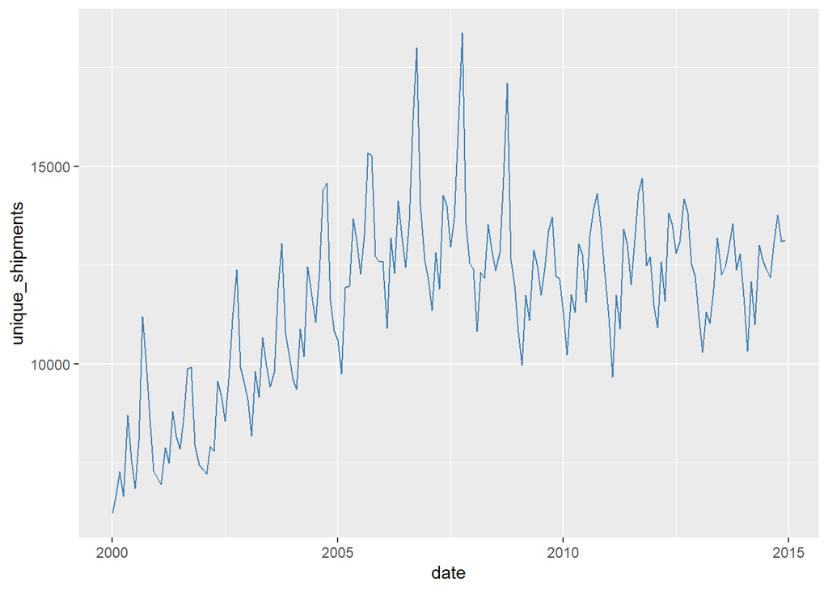

```r
unique_shipments_year <-data %>%
  group_by(year= year(shipment_date),month = month(shipment_date)) %>%
  summarise(unique_shipments = n_distinct(control_number))

unique_shipments_year$date <- as.yearmon(paste(unique_shipments_year$year,
                                          unique_shipments_year$month), "%Y %m")

ggplot(unique_shipments_year, aes(x = date, y = unique_shipments)) +
  geom_line(color='steelblue') + scale_x_continuous()
```

Let’s see the pattern depending on the week of the year

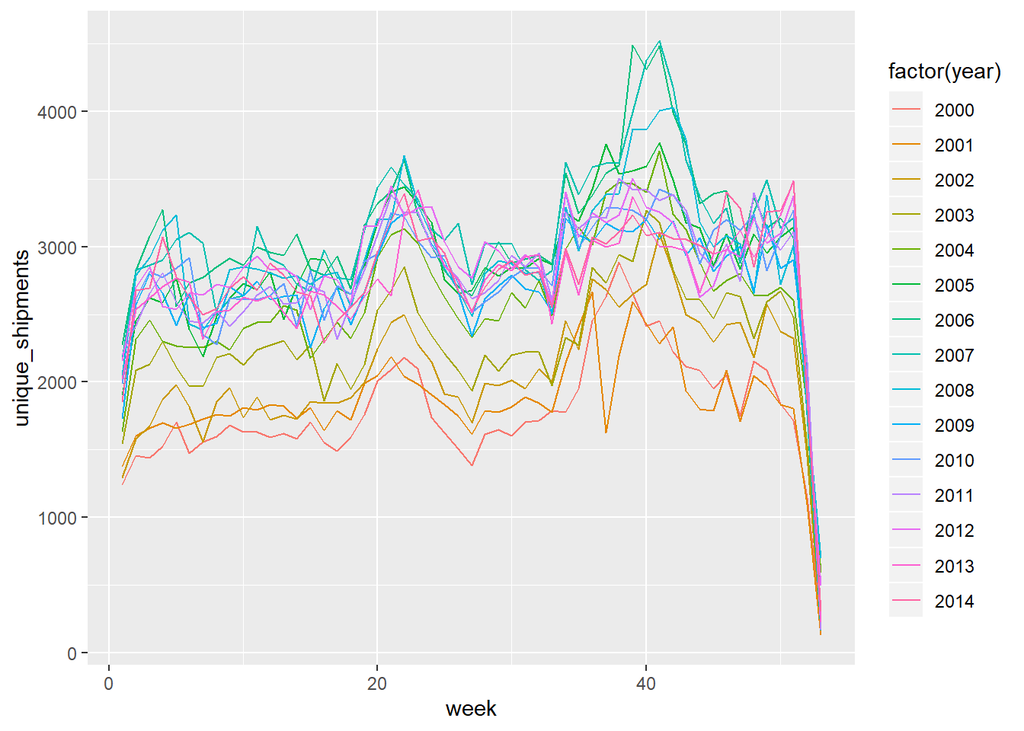

```r
unique_shipments_week <-data %>%
  group_by(year= year(shipment_date), week=week(shipment_date)) %>%
  summarise(unique_shipments = n_distinct(control_number))

ggplot(unique_shipments_week, aes(x = week, y = unique_shipments, color=factor(year))) +
  geom_line()
```

```r
rm(unique_shipments_year)
rm(unique_shipments_week)
```

#### 2.1.2. quantity

**It represents the numeric quantity of the wildlife product** Let’s check the total quantity per month.

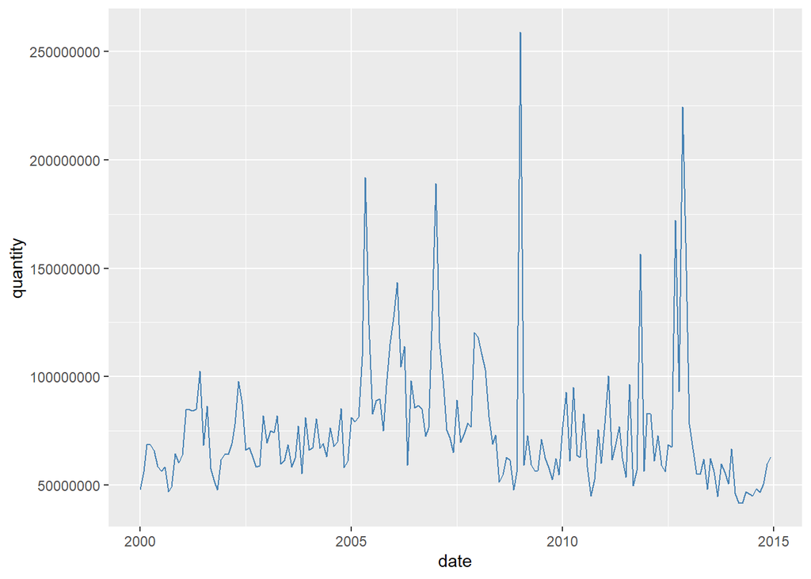

```r
quantity_per_month <-data %>%
  group_by(year= year(shipment_date),month = month(shipment_date)) %>%
  summarise(quantity = sum(quantity))

quantity_per_month$date <- as.yearmon(paste(quantity_per_month$year,
                                          quantity_per_month$month), "%Y %m")

ggplot(quantity_per_month, aes(x = date, y = quantity)) +
  geom_line(color='steelblue') + scale_x_continuous()
```

#### 2.1.3. Imports and exports

**It represents Whether the shipment is an (I)mport or (E)xport**. In this dataset, 100% of the data is an import.

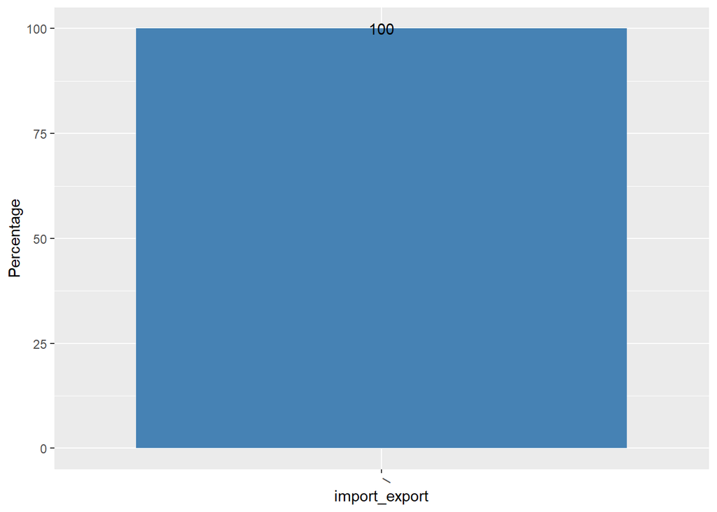

```r
data %>% group_by(import_export) %>%
  summarise(total=n()/nrow(data)*100) %>%
  ggplot(aes(x=import_export, y=total)) +
  geom_bar(stat="identity",fill="steelblue") +
  geom_text(aes(label=round(total,2)))+
  theme(axis.text.x = element_text(angle=60, hjust=1)) +
  labs(y = "Percentage",  x="import_export")
```

### 2.2. EXPLORATORY ANALYSIS: identifying the wildlife or wildlife product

**The ‘control_number’ represents a unique individual shipment. The ‘species_code’, ‘taxa’, ‘class’, ‘genus’, ‘species’,‘subspecies’, ‘specifc_name’, and ‘generic_name’ columns all provide information serving to identify the wildlife or wildlife product.**

#### 2.2.1. species_code

**It represents the USFWS code for the wildlife product**

- There are 15,526 unique species codes
- The top 15 represents 29.7% of data
- The top 50 represents 50.2% of data

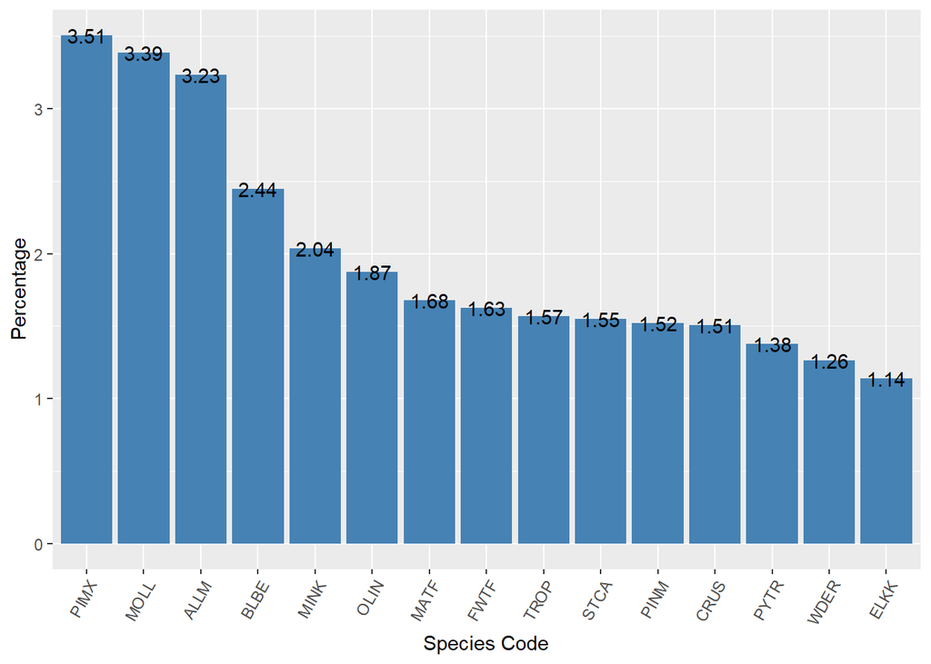

```r
species_code <-data %>% group_by(species_code) %>%
  summarise(total=n()/nrow(data) *100) %>%
  arrange(desc(total)) %>% top_n(15, total)

ggplot(data=species_code, aes(x=reorder(species_code, -total), y=total)) +
  geom_bar(stat="identity",fill="steelblue") +
  geom_text(aes(label=round(total,2)))+
  theme(axis.text.x = element_text(angle=60, hjust=1)) +
  labs(y = "Percentage",  x="Species Code")
```

```r
rm(species_code)
```

#### 2.2.2. taxa

**It represents the USFWS-derived broad taxonomic categorization**

- There are 14 taxa levels
- There is a ‘taxa’ field for the vast majority (>99%) of records
- Most of them are mammals (28.84%), follow by shells (20.11%), reptiles (13.14%) and corals (12.48%). These four categories represent 74,59% of data

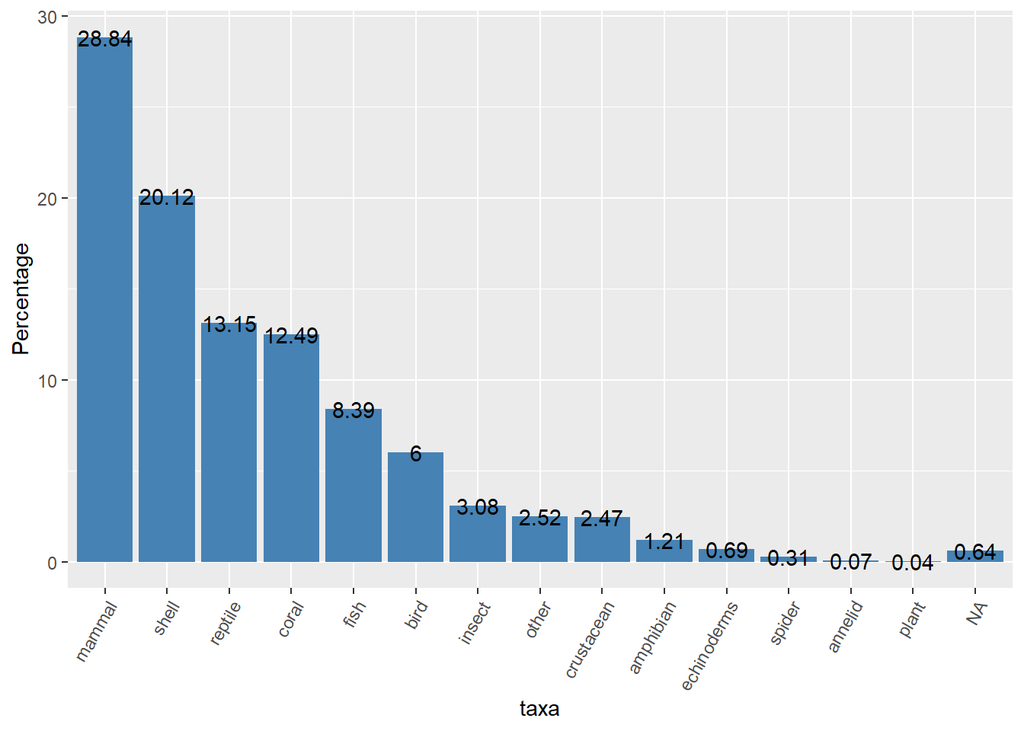

```r
taxa <-data %>% group_by(taxa) %>%
  summarise(total=n()/nrow(data)*100) %>%
  arrange(desc(total))

ggplot(data=taxa, aes(x=reorder(taxa, -total), y=total)) +
  geom_bar(stat="identity",fill="steelblue") +
  geom_text(aes(label=round(total,2)))+
  theme(axis.text.x = element_text(angle=60, hjust=1)) +
  labs(y = "Percentage",  x="taxa")
```

```r
rm(taxa)
```

#### 2.2.3. class

**It represents the EHA-derived class-level taxonomic designation**

- There are 63 classes
- The top 15 represents 91.96% of data

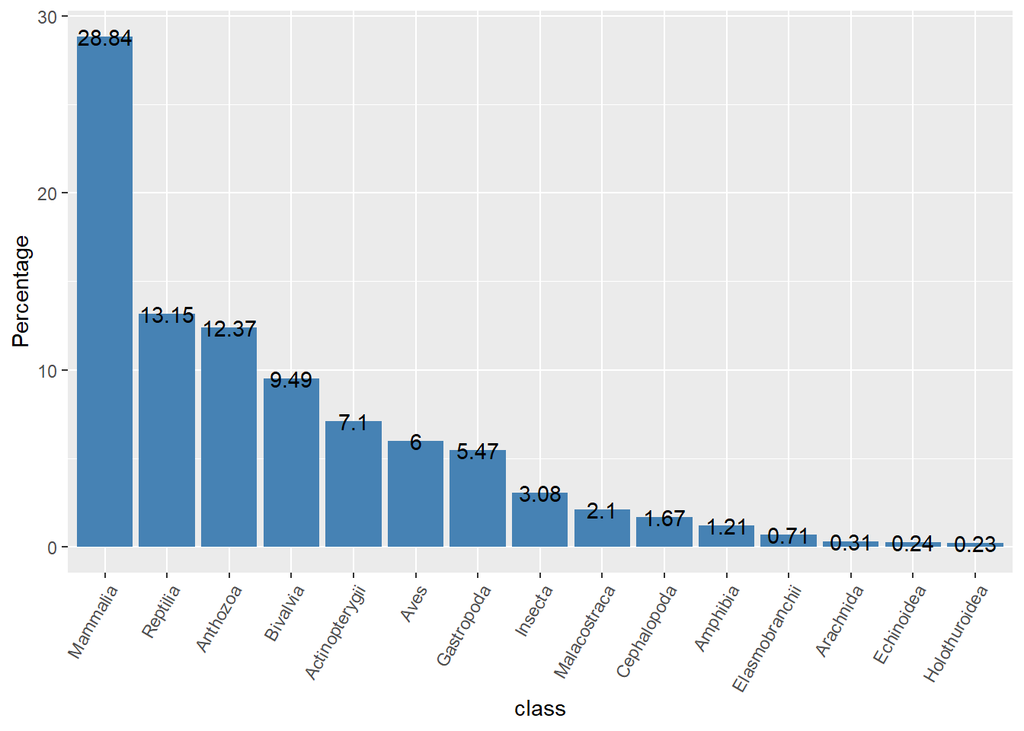

```r
class <-data %>% group_by(class) %>%
  summarise(total=n()/nrow(data) *100) %>%
  drop_na(class) %>%
  arrange(desc(total)) %>% top_n(15, total)

ggplot(data=class, aes(x=reorder(class, -total), y=total)) +
  geom_bar(stat="identity",fill="steelblue") +
  geom_text(aes(label=round(total,2)))+
  theme(axis.text.x = element_text(angle=60, hjust=1)) +
  labs(y = "Percentage",  x="class")
```

```r
rm(class)
```

#### 2.2.4. genus

**It represents the Genus (or higher-level taxonomic name) of the wildlife product**

- There are 6506 genus levels
- The top 15 represents 33.4% of data
- The top 50 represents 57.0% of data

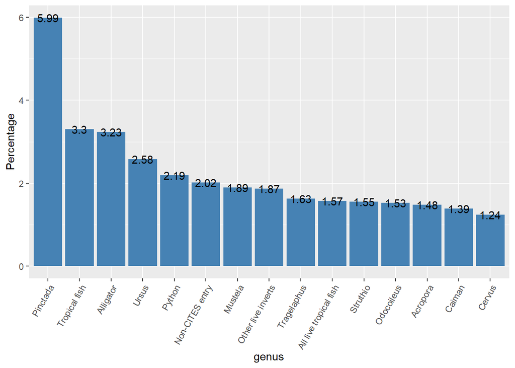

```r
genus <-data %>% group_by(genus) %>%
  summarise(total=n()/nrow(data) *100) %>%
  drop_na(genus) %>%
  arrange(desc(total)) %>% top_n(15, total)

ggplot(data=genus, aes(x=reorder(genus, -total), y=total)) +
  geom_bar(stat="identity",fill="steelblue") +
  geom_text(aes(label=round(total,2)))+
  theme(axis.text.x = element_text(angle=60, hjust=1)) +
  labs(y = "Percentage",  x="genus")
```

```r
rm(genus)
```

#### 2.2.5. species

**It represents species of the wildlife product**

- There are 8239 species levels
- The top 15 represents 42.6% of data
- The top 50 represents 61.3% of data

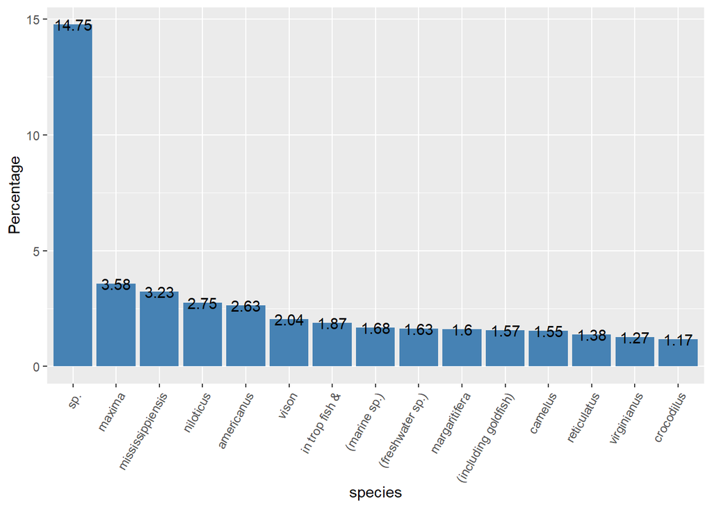

```r
species <-data %>% group_by(species) %>%
  summarise(total=n()/nrow(data) *100) %>%
  drop_na(species) %>%
  arrange(desc(total)) %>% top_n(15, total)

ggplot(data=species, aes(x=reorder(species, -total), y=total)) +
  geom_bar(stat="identity",fill="steelblue") +
  geom_text(aes(label=round(total,2)))+
  theme(axis.text.x = element_text(angle=60, hjust=1)) +
  labs(y = "Percentage",  x="species")
```

```r
rm(species)
```

#### 2.2.6. subspecies

**It represents subspecies of the wildlife product**

- There are 451 subspecies levels
- The top 15 just represents 2.4% of data
- The top 50 just represents 2.5% of data

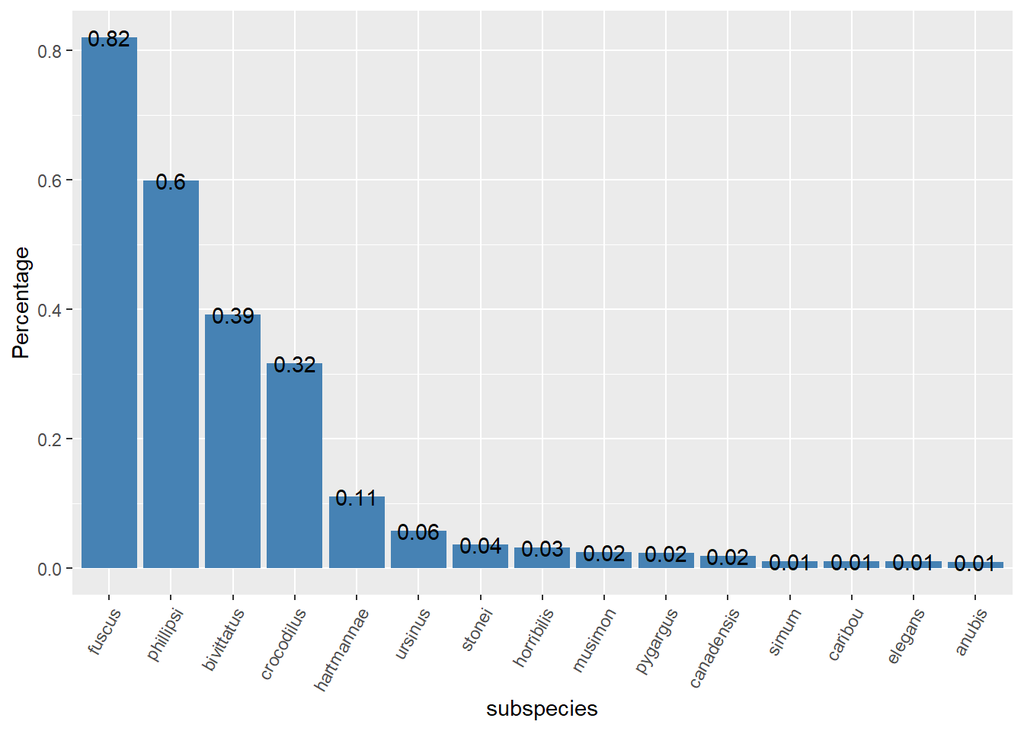

```r
subspecies <-data %>% group_by(subspecies) %>%
  summarise(total=n()/nrow(data) *100) %>%
  filter(subspecies!="other shipments") %>%
  arrange(desc(total)) %>% top_n(15, total)

ggplot(data=subspecies, aes(x=reorder(subspecies, -total), y=total)) +
  geom_bar(stat="identity",fill="steelblue") +
  geom_text(aes(label=round(total,2)))+
  theme(axis.text.x = element_text(angle=60, hjust=1)) +
  labs(y = "Percentage",  x="subspecies")
```

```r
rm(subspecies)
```

#### 2.2.7. specific_name

**It represents a specific common name for the wildlife product**

- There are 6734 specific names levels
- The top 15 represents 29.5% of data
- The top 50 represents 45.6% of data

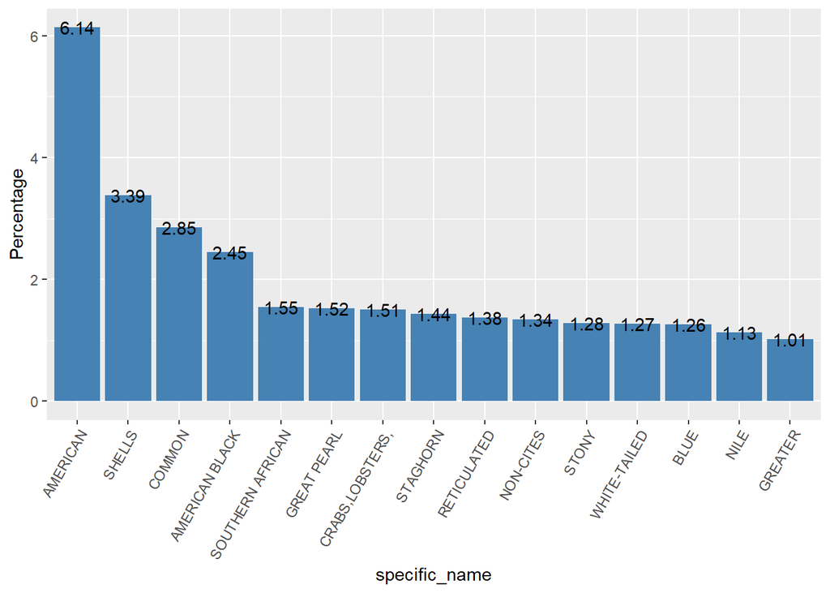

```r
specific_name <-data %>% group_by(specific_name) %>%
  summarise(total=n()/nrow(data) *100) %>%
  drop_na(specific_name) %>%
  arrange(desc(total)) %>% top_n(15, total)

ggplot(data=specific_name, aes(x=reorder(specific_name, -total), y=total)) +
  geom_bar(stat="identity",fill="steelblue") +
  geom_text(aes(label=round(total,2)))+
  theme(axis.text.x = element_text(angle=60, hjust=1)) +
  labs(y = "Percentage",  x="specific_name")
```

```r
rm(specific_name)
```

#### 2.2.8. generic_name

**It represents a general common name for the wildlife product**

- There are 2099 generic names levels
- The top 15 represents 48.7% of data
- The top 50 represents 70.8% of data

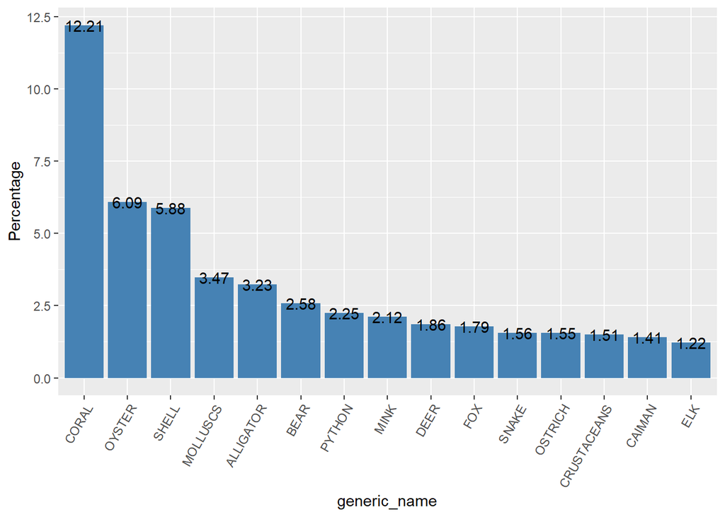

```r
generic_name <-data %>% group_by(generic_name) %>%
  summarise(total=n()/nrow(data) *100) %>%
  drop_na(generic_name) %>%
  arrange(desc(total)) %>% top_n(15, total)

ggplot(data=generic_name, aes(x=reorder(generic_name, -total), y=total)) +
  geom_bar(stat="identity",fill="steelblue") +
  geom_text(aes(label=round(total,2)))+
  theme(axis.text.x = element_text(angle=60, hjust=1)) +
  labs(y = "Percentage",  x="generic_name")
```

```r
rm(generic_name)
```

### 2.3. EXPLORATORY ANALYSIS: countries

#### 2.3.1. country_origin

**It represents the code for the country of origin of the wildlife product**

- There are 252 countries of origin
- The top 15 represents 74.2% of data
- The top 50 represents 94.3% of data

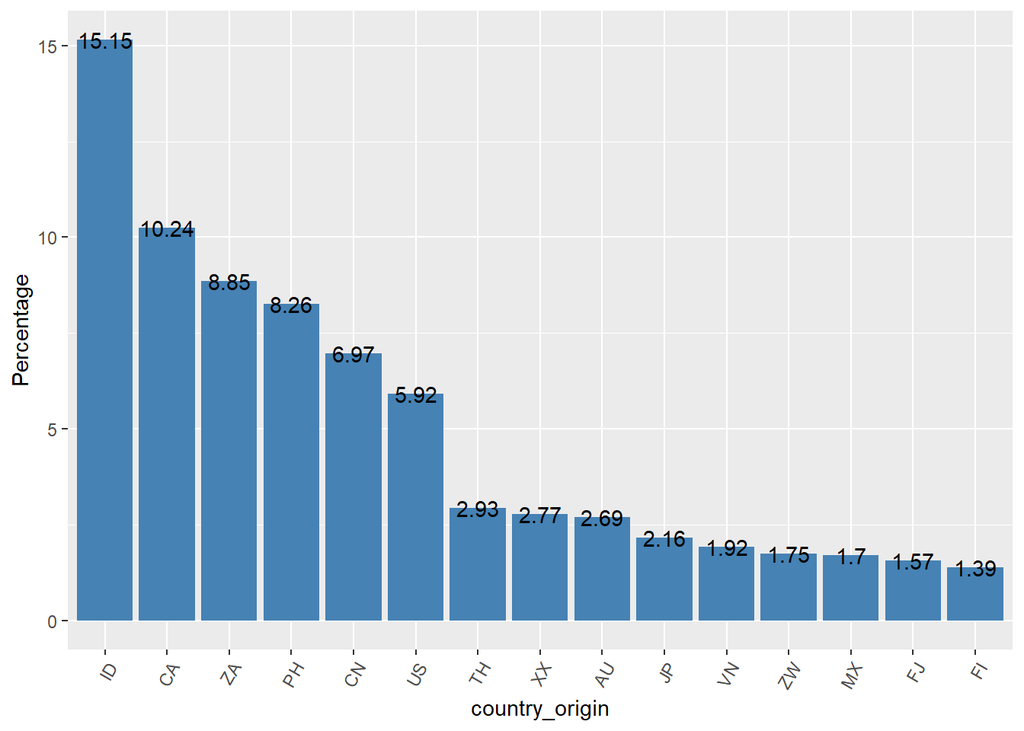

```r
country_origin <-data %>% group_by(country_origin) %>%
  summarise(total=n()/nrow(data) *100) %>%
  drop_na(country_origin) %>%
  arrange(desc(total)) %>% top_n(15, total)

ggplot(data=country_origin, aes(x=reorder(country_origin, -total), y=total)) +
  geom_bar(stat="identity",fill="steelblue") +
  geom_text(aes(label=round(total,2)))+
  theme(axis.text.x = element_text(angle=60, hjust=1)) +
  labs(y = "Percentage",  x="country_origin")
```

#### 2.3.2. country_imp_exp

**It represents the code for the country to/from which the wildlife product is shipped**

- There are 257 countries to/from which the product is shipped
- The top 15 represents 75.6% of data
- The top 50 represents 95.8% of data

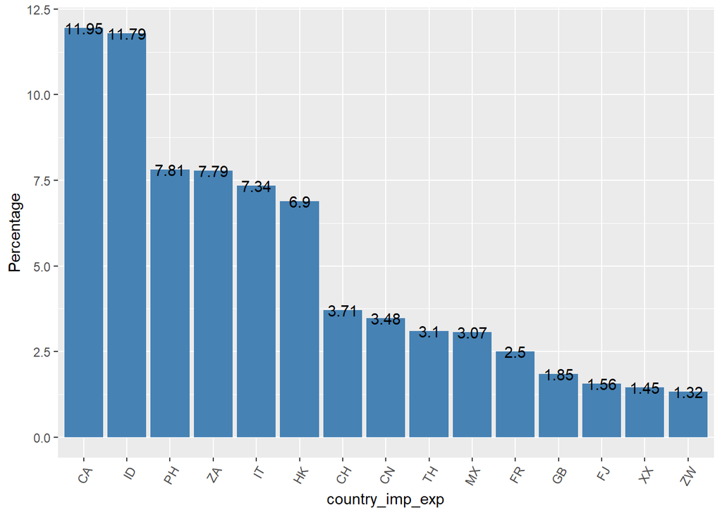

```r
country_imp_exp <-data %>% group_by(country_imp_exp) %>%
  summarise(total=n()/nrow(data) *100) %>%
  drop_na(country_imp_exp) %>%
  arrange(desc(total)) %>% top_n(15, total)

ggplot(data=country_imp_exp, aes(x=reorder(country_imp_exp, -total), y=total)) +
  geom_bar(stat="identity",fill="steelblue") +
  geom_text(aes(label=round(total,2)))+
  theme(axis.text.x = element_text(angle=60, hjust=1)) +
  labs(y = "Percentage",  x="country_imp_exp")
```

**Most problematic countries are on both sides (country of origin & country to/from which the wildlife product is shipped)**

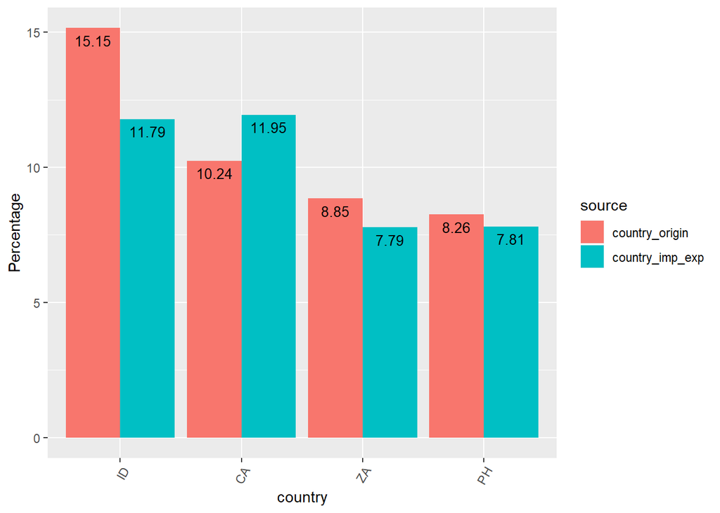

```r
country_origin <-data %>% group_by(country_origin) %>%
  summarise(total=n()/nrow(data) *100) %>%
  drop_na(country_origin) %>%
  arrange(desc(total)) %>% top_n(4, total) %>%
  rename(country = country_origin)

country_imp_exp <-data %>% group_by(country_imp_exp) %>%
  summarise(total=n()/nrow(data) *100) %>%
  drop_na(country_imp_exp) %>%
  arrange(desc(total)) %>% top_n(4, total) %>%
  rename(country = country_imp_exp)

countries<- combine(country_origin, country_imp_exp)

ggplot(data=countries, aes(x=reorder(country, -total), y=total, fill=source)) +
geom_bar(stat="identity", position=position_dodge())+
  geom_text(aes(label=round(total,2)),vjust=1.6,position = position_dodge(0.9), size=3.5)+
  theme(axis.text.x = element_text(angle=60, hjust=1)) +
  labs(y = "Percentage",  x="country")
```

```r
rm(country_origin)
rm(country_imp_exp)
```

#### 2.3.3. port

**It represents the port or region of shipment entry**

- There are 73 ports
- The top 15 represents 83.8% of data

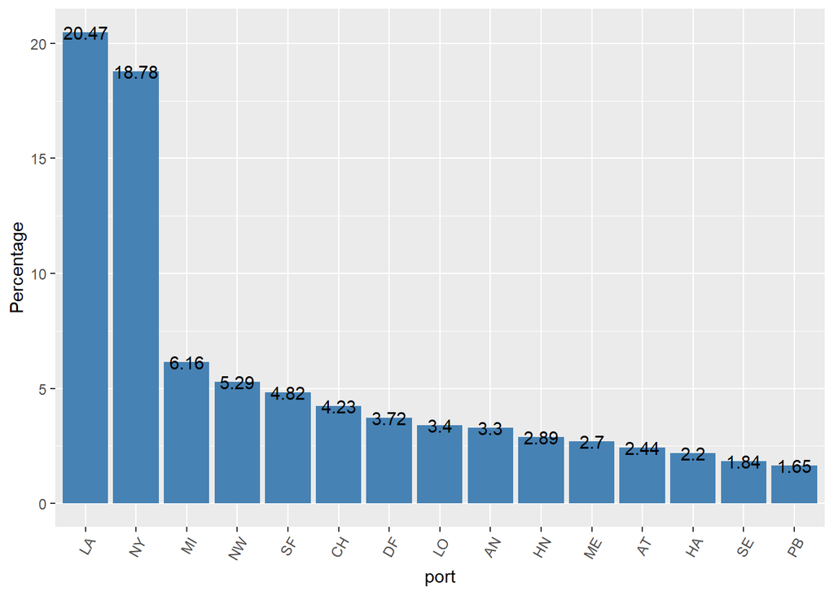

```r
port <-data %>% group_by(port) %>%
  summarise(total=n()/nrow(data) *100) %>%
  drop_na(port) %>%
  arrange(desc(total)) %>% top_n(15, total)

ggplot(data=port, aes(x=reorder(port, -total), y=total)) +
  geom_bar(stat="identity",fill="steelblue") +
  geom_text(aes(label=round(total,2)))+
  theme(axis.text.x = element_text(angle=60, hjust=1)) +
  labs(y = "Percentage",  x="port")
```

```r
rm(port)
```

#### 2.3.4. us_co

**It represents the US party of the shipment**

- There are 126,751 US parties
- The top 15 just represents 10.2% of data
- The top 50 just represents 18.9% of data

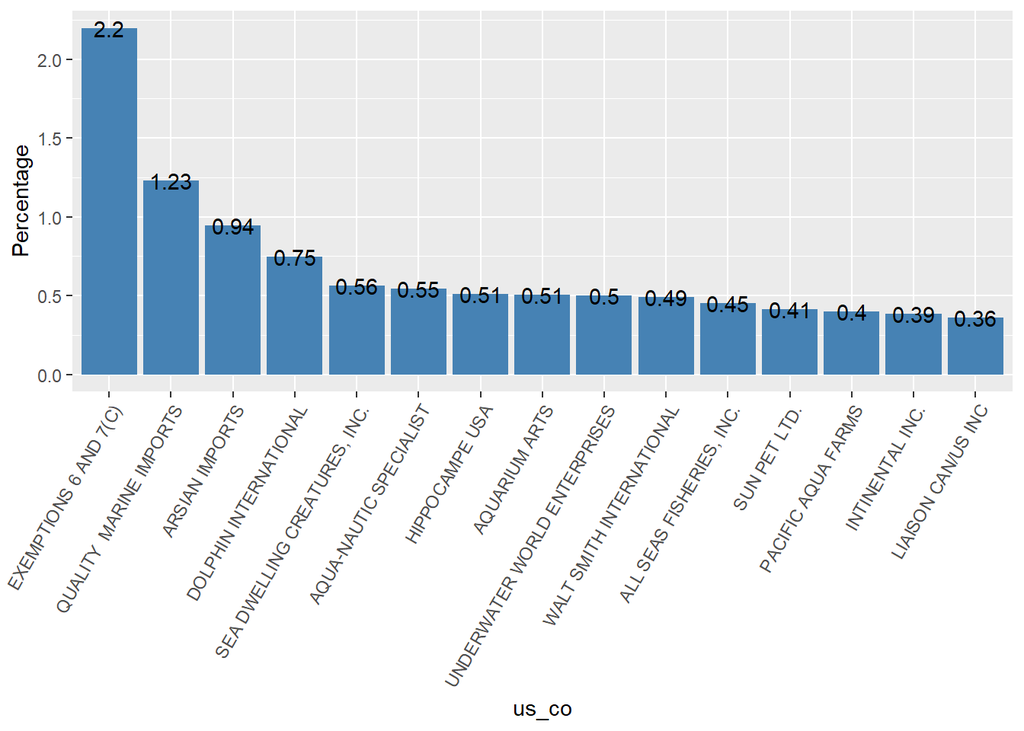

```r
us_co <-data %>% group_by(us_co) %>%
  summarise(total=n()/nrow(data) *100) %>%
  drop_na(us_co) %>%
  arrange(desc(total)) %>% top_n(15, total)

ggplot(data=us_co, aes(x=reorder(us_co, -total), y=total)) +
  geom_bar(stat="identity",fill="steelblue") +
  geom_text(aes(label=round(total,2)))+
  theme(axis.text.x = element_text(angle=60, hjust=1)) +
  labs(y = "Percentage",  x="us_co")
```

```r
rm(us_co)
```

#### 2.3.5. foreign_co

**It represents the foreign party of the shipment**

- There are 237,994 foreign parties
- The top 15 just represents 5.3% of data
- The top 50 just represents 12.3% of data

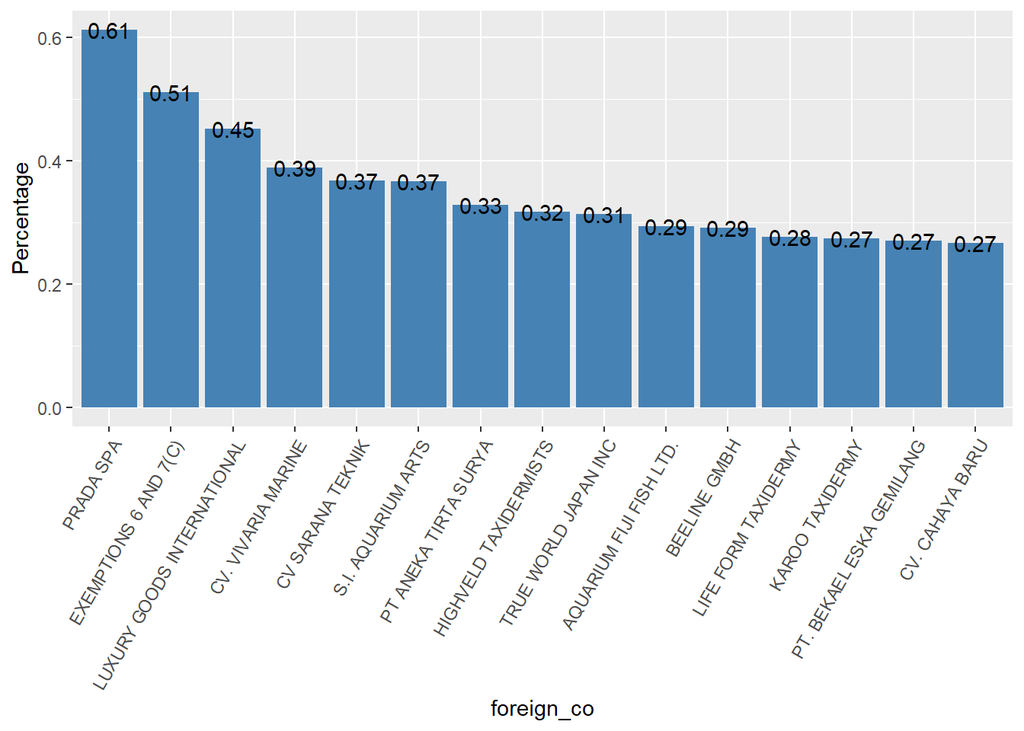

```r
foreign_co <-data %>% group_by(foreign_co) %>%
  summarise(total=n()/nrow(data) *100) %>%
  drop_na(foreign_co) %>%
  arrange(desc(total)) %>% top_n(15, total)

ggplot(data=foreign_co, aes(x=reorder(foreign_co, -total), y=total)) +
  geom_bar(stat="identity",fill="steelblue") +
  geom_text(aes(label=round(total,2)))+
  theme(axis.text.x = element_text(angle=60, hjust=1)) +
  labs(y = "Percentage",  x="foreign_co")
```

```r
rm(foreign_co)
```

### 2.4. EXPLORATORY ANALYSIS: disposition

#### 2.4.1. disposition

**It represents the fate of the import**

- There are 5 categories: C, S, A, R and non-standard value
- The C category represents 98.3% of data

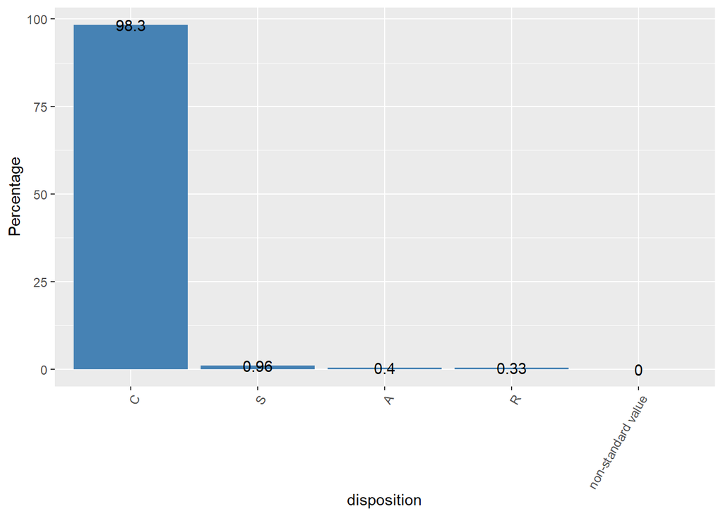

```r
disposition <-data %>% group_by(disposition) %>%
  summarise(total=n()/nrow(data) *100) %>%
  drop_na(disposition) %>%
  arrange(desc(total))

ggplot(data=disposition, aes(x=reorder(disposition, -total), y=total)) +
  geom_bar(stat="identity",fill="steelblue") +
  geom_text(aes(label=round(total,2)))+
  theme(axis.text.x = element_text(angle=60, hjust=1)) +
  labs(y = "Percentage",  x="disposition")
```

```r
rm(disposition)
```

#### 2.4.2. disposition_date

**It represents the full date when disposition occurred**

- While ‘shipment_date’ entries fell completely within the time period of 2000–2014, ‘disposition_date’ ranged more widely
- Users should be wary of any disposition date values that precede the associated shipment date, as we are unaware of how this could represent an accurate accounting of the product disposition process. However, for many potential analyses, differences in the date fields may not be a significant cause for concern because ‘shipment_date’ alone provides a sound index for those interested in temporal trends in wildlife trade

**It seems that 54% occur within a month of the shipment date (most of them within a week)**

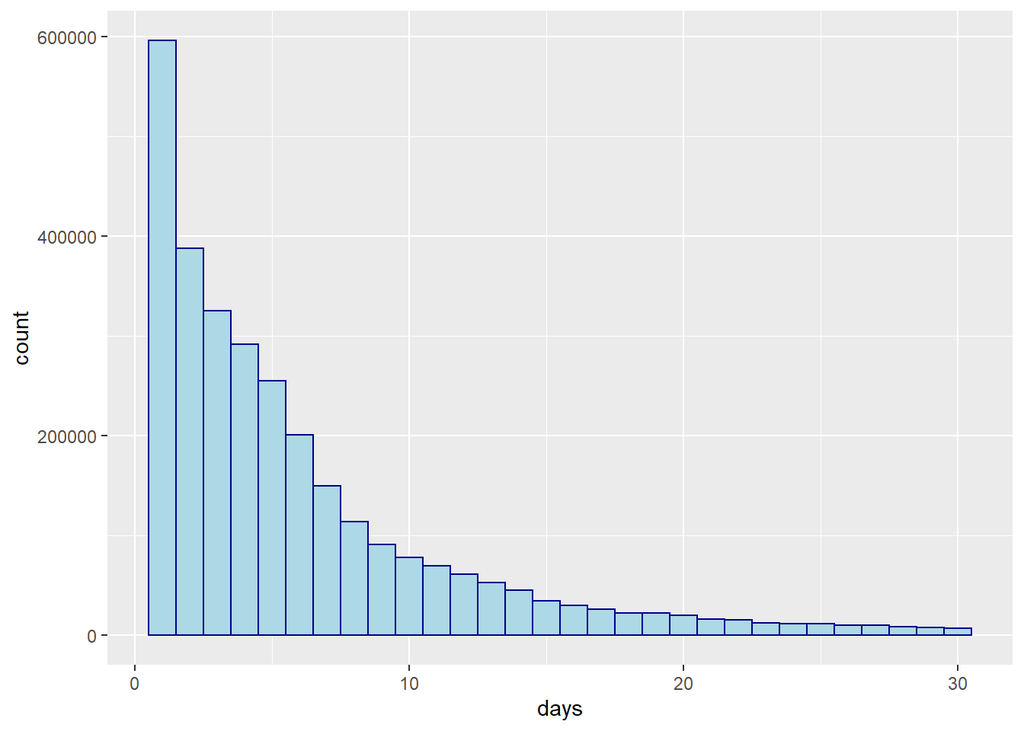

```r
days<- data %>%
  mutate(days = as.numeric(disposition_date - shipment_date)) %>%
  filter(days > 0 & days < 31)

ggplot(days, aes(x=days))+
  geom_histogram(color="darkblue", fill="lightblue")
```

```r
rm(days)
```

#### 2.4.3. action

**Action taken by USFWS on import ((C)leared/(R)efused)**

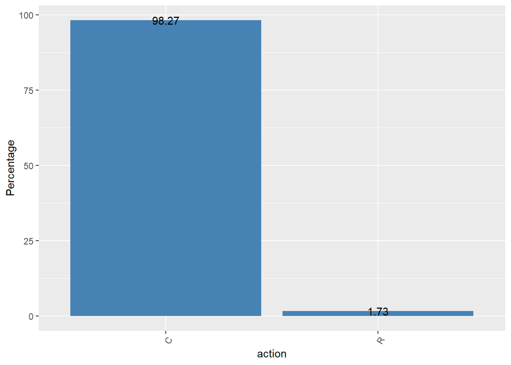

```r
action <-data %>% group_by(action) %>%
  summarise(total=n()/nrow(data) *100) %>%
  drop_na(action) %>%
  arrange(desc(total))

ggplot(data=action, aes(x=reorder(action, -total), y=total)) +
  geom_bar(stat="identity",fill="steelblue") +
  geom_text(aes(label=round(total,2)))+
  theme(axis.text.x = element_text(angle=60, hjust=1)) +
  labs(y = "Percentage",  x="action")
```

```r
rm(action)
```

### 2.5. EXPLORATORY ANALYSIS: wildlife product

#### 2.5.1. description

**It represents the type/form of the wildlife product**

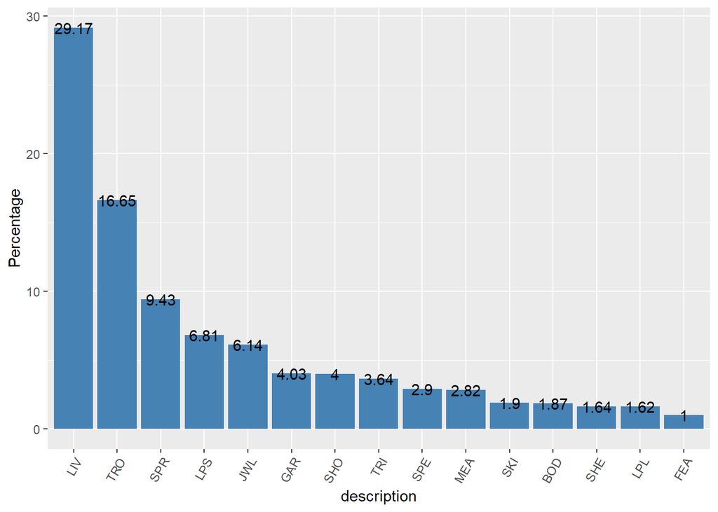

```r
description <-data %>% group_by(description) %>%
  summarise(total=n()/nrow(data) *100) %>%
  drop_na(description) %>%
  arrange(desc(total)) %>% top_n(15, total)

ggplot(data=description, aes(x=reorder(description, -total), y=total)) +
  geom_bar(stat="identity",fill="steelblue") +
  geom_text(aes(label=round(total,2)))+
  theme(axis.text.x = element_text(angle=60, hjust=1)) +
  labs(y = "Percentage",  x="description")
```

```r
rm(description)
```

#### 2.5.2. unit

**It represents the unit for the numeric quantity**

- There are 13 units.
- The NO unit represents 94.5% of data

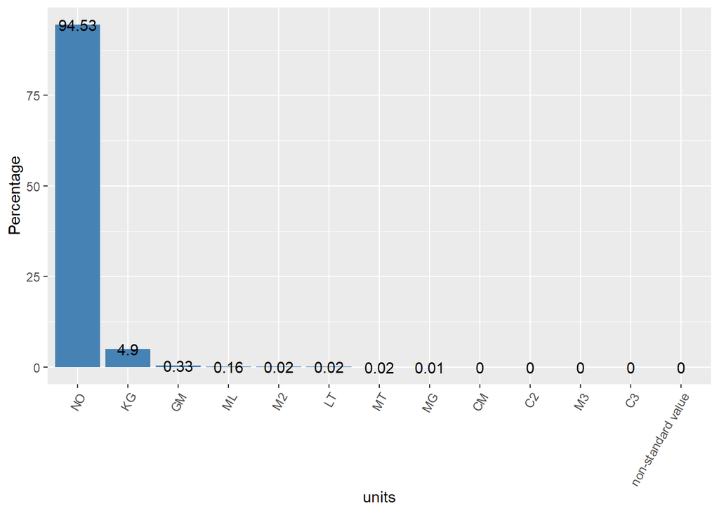

```r
units <-data %>% group_by(unit) %>%
  summarise(total=n()/nrow(data) *100) %>%
  drop_na(unit) %>%
  arrange(desc(total))

ggplot(data=units, aes(x=reorder(unit, -total), y=total)) +
  geom_bar(stat="identity",fill="steelblue") +
  geom_text(aes(label=round(total,2)))+
  theme(axis.text.x = element_text(angle=60, hjust=1)) +
  labs(y = "Percentage",  x="units")
```

```r
rm(units)
```

#### 2.5.3. value

**It represents the reported value of the wildlife product in US dollars**. Let’s check the value of the most representative taxa levels (mammals, shells, reptiles, corals and fishes)

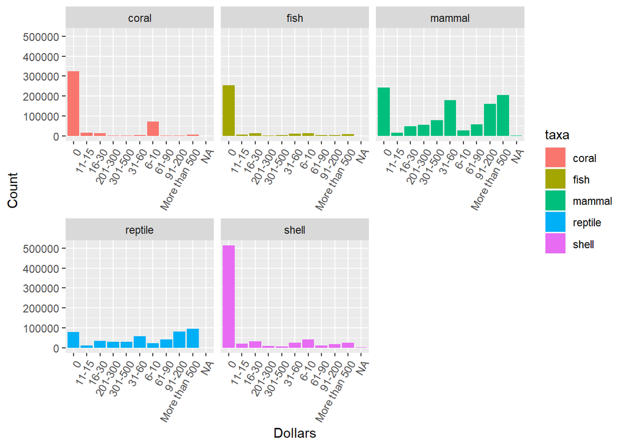

```r
value_taxa<- data %>%
  drop_na(value, taxa) %>%
  mutate(value = value/quantity)  %>%
  filter(!is.infinite(value))  %>%
  filter(taxa == "mammal" | taxa == "shell" | taxa == "reptile" | taxa == "coral" | taxa == "fish") %>%
  select(taxa, value) %>%
  mutate(grouped_value = ifelse(value<6, "0",
                         ifelse(value>=6  & value<=10, "6-10",
                         ifelse(value>=6  & value<=10, "6-10",
                         ifelse(value>=11 & value<=15, "11-15",
                         ifelse(value>=16 & value<=30, "16-30",
                         ifelse(value>=31 & value<=60, "31-60",
                         ifelse(value>=61 & value<=90, "61-90",
                         ifelse(value>=91 & value<=200, "91-200",
                         ifelse(value>=201 & value<=300, "201-300",
                         ifelse(value>=301 & value<=500, "301-500",
                                "More than 500"))))))))))) %>%
  mutate(grouped_value = as.factor(grouped_value)) %>%
  group_by(taxa, grouped_value) %>% summarise(total=n())

ggplot(value_taxa,aes(x=grouped_value,y=total,fill=taxa))+
  geom_bar(stat="identity")+
 theme(axis.text.x = element_text(angle=60, hjust=1)) +
  labs(x="Dollars", y="Count") +
  facet_wrap(~taxa,scales = "free_x" )
```

#### 2.5.4. purpose

**It represents the reason the wildlife product is being imported**

- There are 13 purpose levels
- The T purpose represents 74.51% of the data.

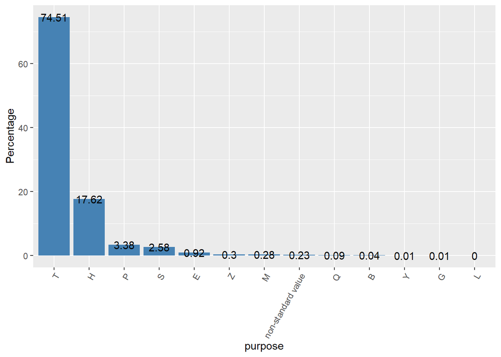

```r
purpose <-data %>% group_by(purpose) %>%
  summarise(total=n()/nrow(data) *100) %>%
  drop_na(purpose) %>%
  arrange(desc(total))

ggplot(data=purpose, aes(x=reorder(purpose, -total), y=total)) +
  geom_bar(stat="identity",fill="steelblue") +
  geom_text(aes(label=round(total,2)))+
  theme(axis.text.x = element_text(angle=60, hjust=1)) +
  labs(y = "Percentage",  x="purpose")
```

```r
rm(purpose)
```

#### 2.5.5. source

**It represents the type of source within the origin country (e.g., wild, bred)**

- There are 10 source levels
- The W source represents 78% of the data.

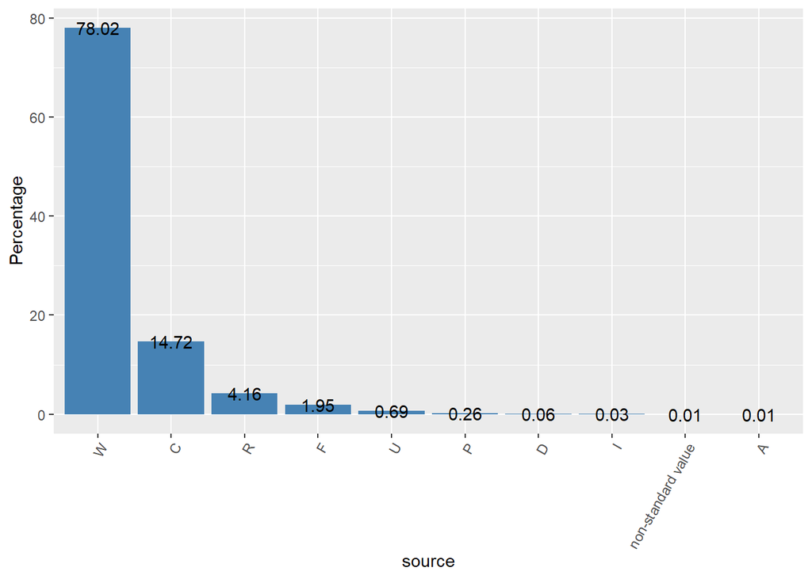

```r
source <-data %>% group_by(source) %>%
  summarise(total=n()/nrow(data) *100) %>%
  drop_na(source) %>%
  arrange(desc(total))

ggplot(data=source, aes(x=reorder(source, -total), y=total)) +
  geom_bar(stat="identity",fill="steelblue") +
  geom_text(aes(label=round(total,2)))+
  theme(axis.text.x = element_text(angle=60, hjust=1)) +
  labs(y = "Percentage",  x="source")
```

```r
rm(source)
```